# Model diagnostics & problems with errors

Mark Scheuerell

17 April 2026

# Background

The models we have been discussing in class assume that the errors are *independent and identically distributed* (IID). In this lab we will explore some options for identifying problems with our errors, and taking corrective actions after we identify them.

# Checking error assumptions

## Constant variance

Let’s begin with the notion of “identically distributed”, which suggests no change in the variance across the model space. For example, if our errors are assumed to be normally distributed, such that

$$e_i \sim \text{N}(0, \sigma^2) ~ \Rightarrow ~ \mathbf{e} \sim
\text{MVN}(\mathbf{0}, \sigma^2 \mathbf{I})$$

then we expect no difference in $\sigma^2$ among any of the $e_i$.

### Residuals versus fitted values

To check this assumption, we can plot our estimates of the residuals $e_i = y- \hat{y}$ against our fitted values $\hat{y}_i$ and look for any patterns. Here are three examples of simple linear regression models fit to to three simulated data sets. The first is linear, but the other two exhibit some classical problems.

```r
set.seed(666)
## sample size
nn <- 40
## set x & e
xx <- runif(nn, 0, 10)
ee <- rnorm(nn)
## linear model
y1 <- 1 + 0.5 * xx + ee
m1 <- lm(y1 ~ xx)
e1 <- resid(m1)
## log-linear model
y2 <- exp(0.1 + 0.3 * xx + ee)
m2 <- lm(y2 ~ xx)
e2 <- resid(m2)
## quadratic model
y3 <- 0.2 * (xx - 5)^2 - 1 + ee
m3 <- lm(y3 ~ xx)
e3 <- resid(m3)
```

We can plot the residuals against the fitted value and check for problems.

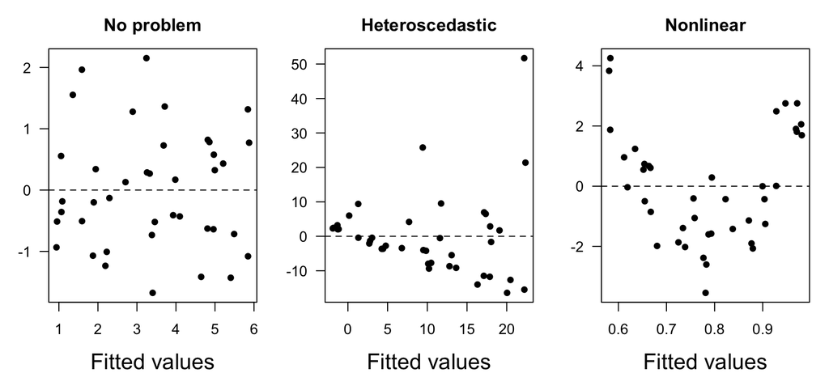

```r
## set plot area
par(mfrow = c(1,3),
    mai = c(0.9,0.5,0.5,0.2),
    omi = c(0, 0, 0, 0),
    cex = 0.9)
## plot errors
## well behaved errors (left)
plot(fitted(m1), e1, pch = 16, las = 1, xpd = NA,
     cex.lab = 1.5, xlab = "Fitted values", ylab = "Residuals",
     main = "No problem")
abline(h = 0, lty ="dashed")
## heteroscedastic errors (middle)
plot(fitted(m2), e2, pch = 16, las = 1,
     cex.lab = 1.5, xlab = "Fitted values", ylab = "",
     main = "Heteroscedastic")
abline(h = 0, lty ="dashed")
## nonlinear errors (right)
plot(fitted(m3), e3, pch = 16, las = 1,
     cex.lab = 1.5, xlab = "Fitted values", ylab = "",
     main = "Nonlinear")
abline(h = 0, lty ="dashed")
```

### Levene’s test

We can formally test the assumption of homogeneous variance via *Levene’s Test*, which compares the absolute values of the residuals in $j$ groups of data to their group mean, such that

$$Z_{ij} = \left| y_{ij} - \bar{y}_j \right|.$$

Levene’s test is a one-way ANOVA of this absolute difference in the residuals. The statistic for *Levene’s Test* is

$$W=\frac{(n-k)}{(k-1)} \cdot \frac{\sum_{j=1}^{k} n_{j} \left( Z_{j} -
\bar{Z} \right)^{2} }{ \sum_{j=1}^{k} \sum_{i=1}^{n_{j} } \left( Z_{i j}
- \bar{Z_{i} } \right)^{2} }$$
where

- $k$ is the number of different groups in the test
- $n_j$ is the number of observations in the $j$<sup>th</sup> group
- $n$ is the total number of observations
- $\bar{Z_{i}}$ is the mean of the $Z_{ij}$ in group $j$
- $\bar{Z}$ is the overall mean of all the $Z_{ij}$

The test statistic $W$ is approximately $F$-distributed with $k-1$ and $n-k$ degrees of freedom.

Levene’s test is easy to compute in **R**. Here is the test for the “well behaved” residuals from model `m1` above.

```r
## split residuals (e1) into 2 groups
yh <- fitted(m1)
g1 <- e1[yh <= median(yh)]
g2 <- e1[yh > median(yh)]
## Levene's test
var.test(g1, g2)
```

```
##
##  F test to compare two variances
##
## data:  g1 and g2
## F = 1.1424, num df = 19, denom df = 19, p-value = 0.7747
## alternative hypothesis: true ratio of variances is not equal to 1
## 95 percent confidence interval:
##  0.4521571 2.8860982
## sample estimates:
## ratio of variances
##           1.142353
```

You can see there is no justification to reject $H_0: \text{Var}(group_1) = \text{Var}(group_2)$ based on the residuals from the well behaved model.

Repeat the test for a set of residuals with clear heteroscedasticity as in the `e2` set above.

```r
## split residuals (e2) into 2 groups
yh <- fitted(m2)
g1 <- e2[yh <= median(yh)]
g2 <- e2[yh > median(yh)]
## Levene's test
var.test(g1, g2)
```

```
##
##  F test to compare two variances
##
## data:  g1 and g2
## F = 0.20077, num df = 19, denom df = 19, p-value = 0.0009907
## alternative hypothesis: true ratio of variances is not equal to 1
## 95 percent confidence interval:
##  0.07946753 0.50723758
## sample estimates:
## ratio of variances
##          0.2007708
```

Here we would reject $H_0$ and conclude that the variances in the two groups are not equal.

## Normality of errors

We seek a method for assessing whether our residuals are indeed normally distributed. The easiest way is via a so-called $Q$-$Q$ plot (for quantile-quantile).

### Normally distributed errors

As we saw in lecture, here are some quantiles for a “standard” normal distribution (ie., the mean is 0 and the variance is 1).

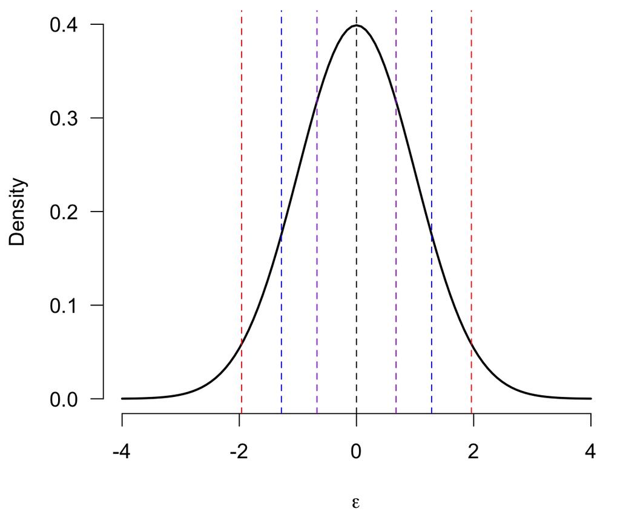

```r
## set plot area
par(mai = c(1,1,0.1,0.1),
    omi = c(0, 0, 0, 0),
    cex = 1.2)

## plot Gaussian pdf
curve(dnorm, -4, 4, las = 1, bty = "n", lwd = 2,
      ylab = "Density", xlab = expression(epsilon))
abline(v = qnorm(c(0.5)), lty = "dashed")
abline(v = qnorm(c(0.25, 0.75)), lty = "dashed", col = "purple")
abline(v = qnorm(c(0.1, 0.9)), lty = "dashed", col = "blue")
abline(v = qnorm(c(0.025, 0.975)), lty = "dashed", col = "red")
```

### Heavy-tailed distribution

In contrast, here are the quantiles for a heavy-tailed (leptokurtic) distribution with the normal distribution above shown in gray for comparison.

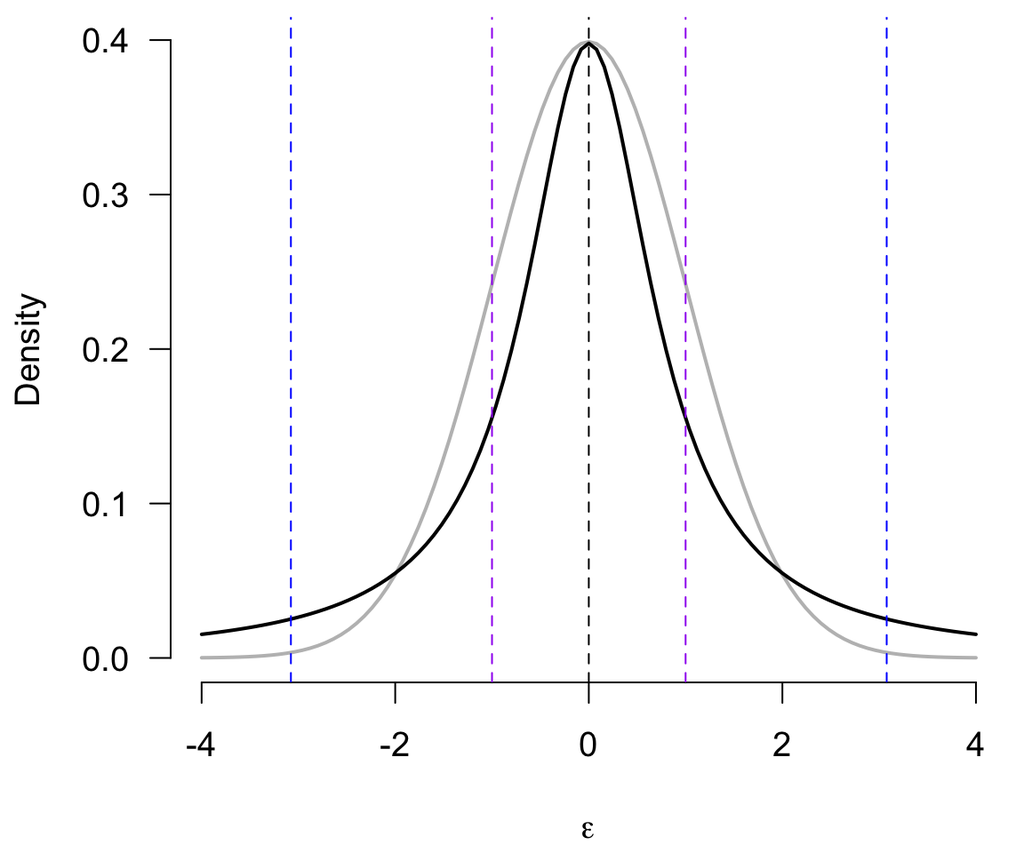

```r
## set plot area
par(mai = c(1,1,0.1,0.1),
    omi = c(0, 0, 0, 0),
    cex = 1.2)

## plot Gaussian pdf
curve(dnorm, -4, 4, las = 1, bty = "n", lwd = 2, col = "gray",
      ylab = "Density", xlab = expression(epsilon))
## plot Cauchy
curve(dcauchy(x, 0, 0.8), -4, 4, las = 1, bty = "n", lwd = 2, add = TRUE,
      ylab = "Density", xlab = expression(epsilon))
abline(v = qcauchy(c(0.5)), lty = "dashed")
abline(v = qcauchy(c(0.25, 0.75)), lty = "dashed", col = "purple")
abline(v = qcauchy(c(0.1, 0.9)), lty = "dashed", col = "blue")
abline(v = qcauchy(c(0.025, 0.975)), lty = "dashed", col = "red")
```

### Short-tailed distribution

Here is a short-tailed (platykurtic) distribution with the normal distribution above shown in gray for comparison. Notice that I made up a pdf based on a [Butterworth function](https://en.wikipedia.org/wiki/Butterworth_filter).

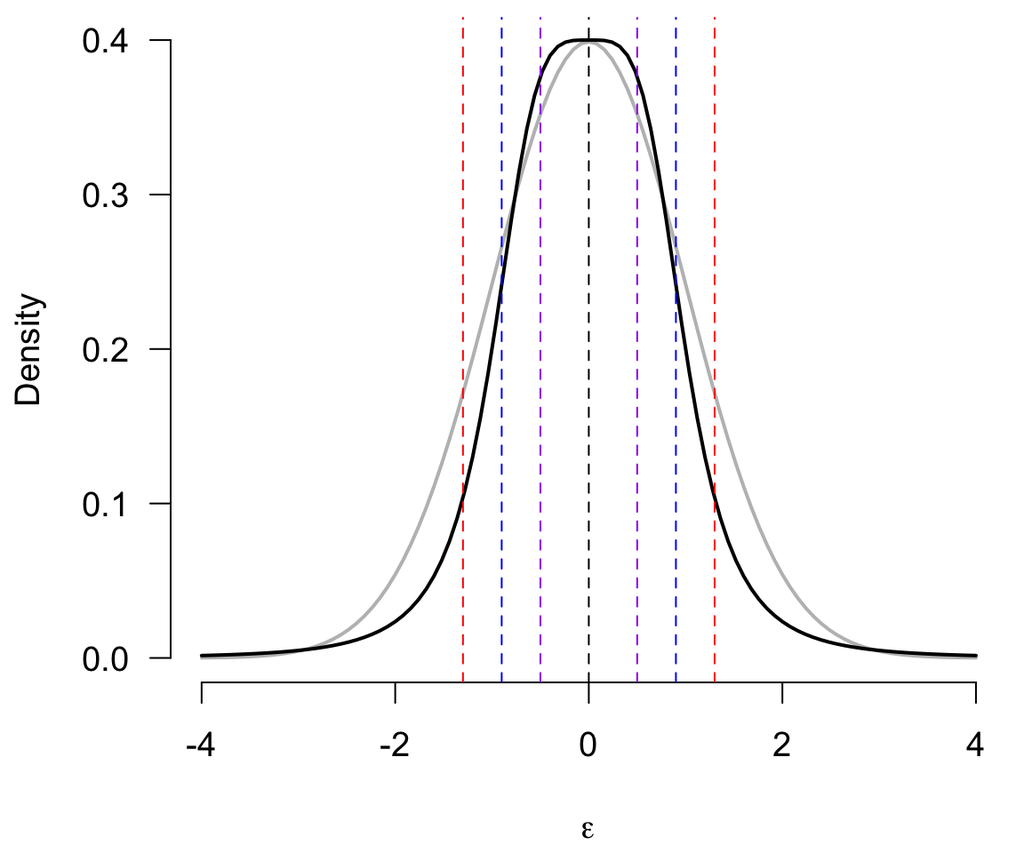

```r
## set plot area
par(mai = c(1,1,0.1,0.1),
    omi = c(0, 0, 0, 0),
    cex = 1.2)

## Butterworth fx
butter <- function(x, c = 1, n = 4) {
  0.4 / (1 + (x / c)^n)
}
ii <- seq(-40,40)/10
ww <- round(butter(ii, 1, 6)*1e4, 0)
vv <- NULL
for(i in 1:length(ww)) {
  tmp <- rep(ii[i], ww[i])
  vv <- c(vv, tmp)
}
qb <- quantile(vv, c(2.5, 10, 25, 50, 75, 90, 97.5)/100)
## plot Gaussian pdf
curve(dnorm, -4, 4, las = 1, bty = "n", lwd = 2, col = "gray",
      ylab = "Density", xlab = expression(epsilon))
## plot Butterworth
curve(butter(x, 1, 4), -4, 4, las = 1, bty = "n", lwd = 2, add = TRUE,
      ylab = "Density", xlab = expression(epsilon))
abline(v = qb[4], lty = "dashed")
abline(v = qb[c(3,5)], lty = "dashed", col = "purple")
abline(v = qb[c(2,6)], lty = "dashed", col = "blue")
abline(v = qb[c(1,7)], lty = "dashed", col = "red")
```

Compare the $Q$-$Q$ plots for these three examples via `qqnorm(x)`.

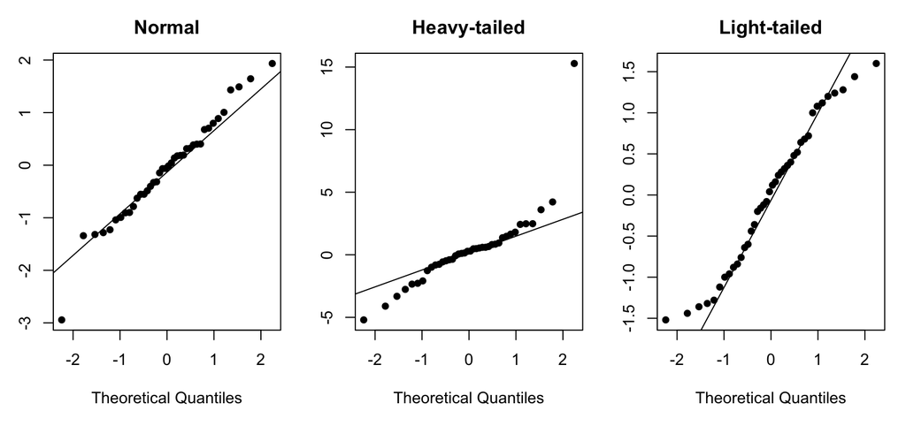

```r
## set plot area
par(mfrow = c(1,3),
    mai = c(0.9,0.5,0.5,0.2),
    omi = c(0, 0, 0, 0),
    cex = 0.9)
## Q-Q plots
## normal
z1 <- rnorm(nn)
qqnorm(z1, pch =16, main = "Normal", xpd = NA)
qqline(z1)
## leptokurtic
z2 <- rcauchy(nn)
qqnorm(z2, pch =16, main = "Heavy-tailed")
qqline(z2)
## platykurtic
ii <- sample(seq(-40,40)/10, nn)
z3 <- butter(ii, nn) * ii
qqnorm(z3, pch =16, main = "Light-tailed")
qqline(z3)
```

## Correlated errors

One component of *IID* errors is “independent”, which means we expect no correlation among any of the errors. This assumption may be violated when working with

- Temporal data
- Spatial data
- Blocked data

For example, let’s examine the data on tree rings and climate proxies in the `globwarm` dataset from the **faraway** package.

Plot tree growth (`wusa`) versus temperature (`nhtemp`).

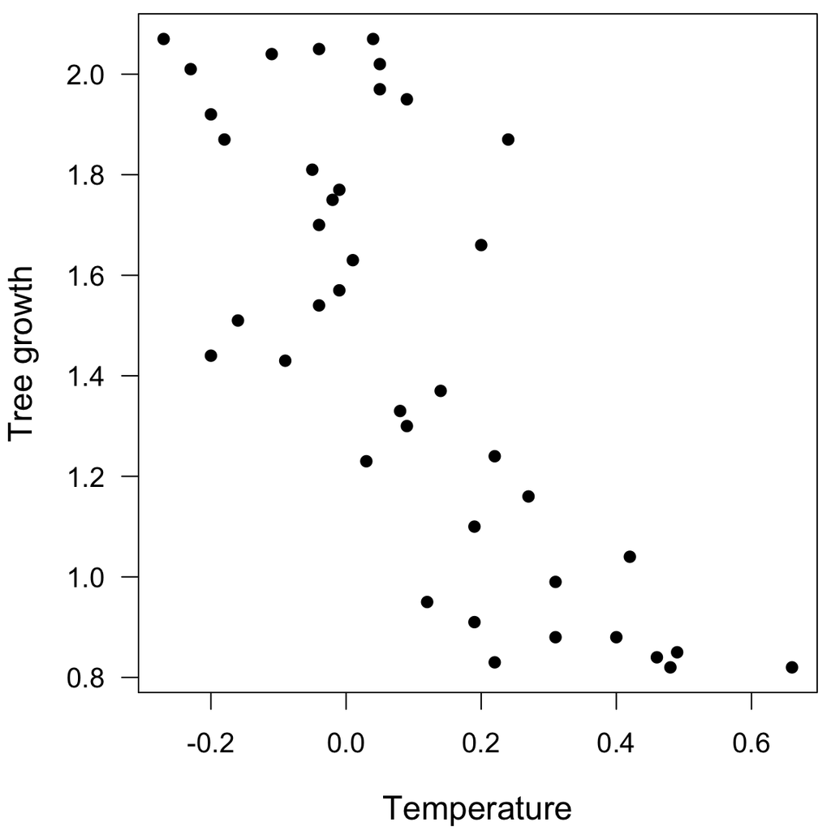

```r
## get raw data
data(globwarm, package = "faraway")
## trim to recent years
dat <- globwarm[globwarm$year > 1960,]

## set plot area
par(mai = c(1,1,0.1,0.1),
    omi = c(0, 0, 0, 0),
    cex = 1.2)

## plot regr
plot(dat$nhtemp, dat$wusa, pch = 16, las = 1, xpd = NA,
     cex.lab = 1.2, xlab = "Temperature", ylab = "Tree growth", main = "")
```

Fit a simple regression model where tree growth (`wusa`) is a function of temperature (`nhtemp`).

```r
## fit a model
mm <- lm(wusa ~ nhtemp, dat)
## extract fits
ff <- fitted(mm)
## extract residuals
ee <- resid(mm)
```

Here is a plot of the residuals versus the fitted values (left) and the residuals at time $t$ against those at time $t+1$ (right). Notice the strong correlation between the residuals.

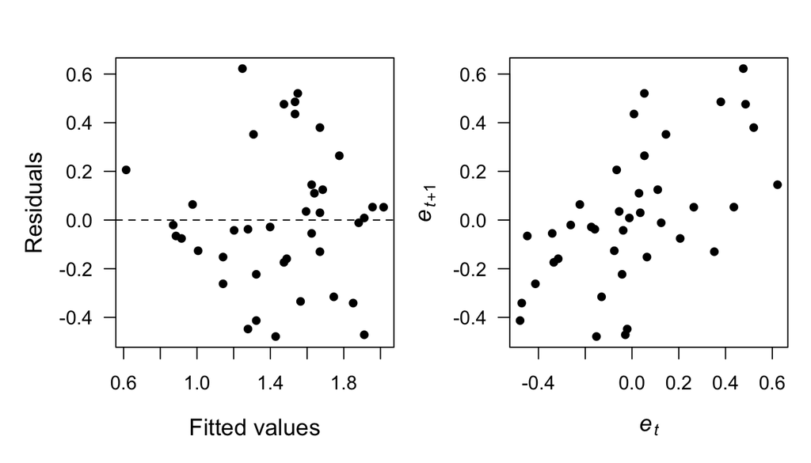

```r
## set plot area
par(mfrow = c(1,2),
    mai = c(0.9, 0.9, 0.1, 0.1),
    omi = c(0.1, 0.1, 0.4, 0.1),
    cex = 1)
## plots
plot(ff, ee, pch = 16, las = 1, xpd = NA,
     cex.lab = 1.2, xlab = "Fitted values", ylab = "Residuals", main = "")
abline(h = 0, lty ="dashed")
plot(ee[1:(length(ee)-1)], ee[2:length(ee)],
     pch = 16, las = 1, cex.lab = 1.2,
     xlab = expression(italic(e[t])),
     ylab = expression(italic(e)[italic(t)+1]),
     main = "")
```

Estimate the *autocorrelation function* of the model residuals with the `acf()` function.

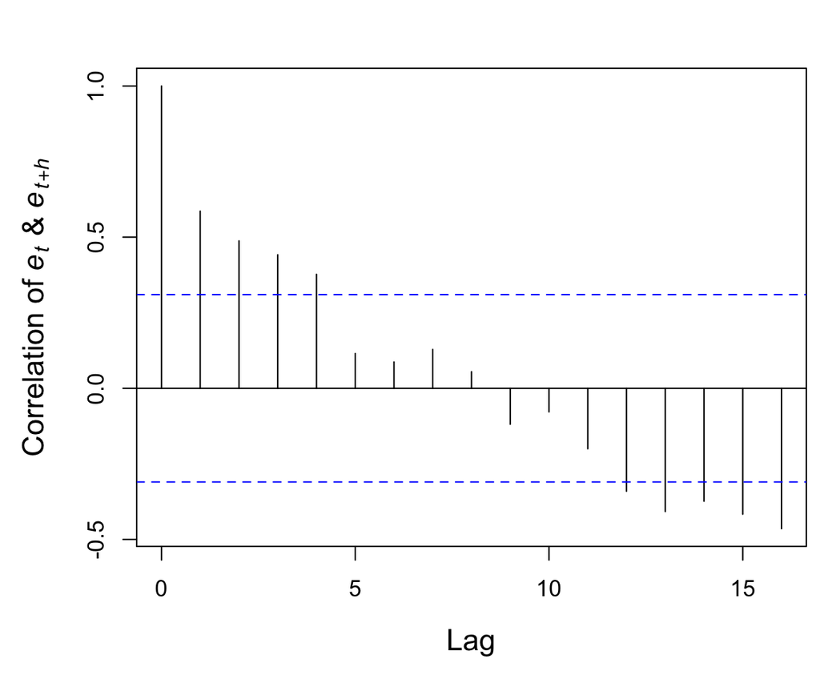

```r
## set plot area
par(mai = c(0.9, 0.9, 0.1, 0.1),
    omi = c(0.1, 0.1, 0.4, 0))
## plot acf
acf(ee,
    ylab = expression(paste("Correlation of ", italic(e[t]), " & ", italic(e[t + h]))),
    main = "", cex.lab = 1.3)
```

This suggests we should instead use a model along the lines of

$$y_t = \mathbf{X}_t \boldsymbol{\beta} + e_t \\
e_t \sim \text{N}(\phi e_{t-1}, \sigma^2).$$

We cannot fit this model using the base function `lm()` in **R**, but we can use the `gls()` function in the [**{nlme}** package](https://cran.r-project.org/web/packages/nlme/index.html).

Specifically, we specify the `correlation` argument using the function `corAR1(value, form, ...)`, which fits a first-order autoregressive model, or AR(1). We can ignore the `value` argument because we want to estimate $\phi$ rather than prescribe it. The `form` argument specifies the time covariate (predictor) as a one-sided formula; here we use `year`. We also need to eliminate the `NA`’s from the data set before passing it to `gls()`.

```r
## load nlme pkg
require(nlme)
## fit model with AR(1) errors
glmod <- gls(wusa ~ nhtemp,
             correlation = corAR1(form = ~ year),
             data = na.omit(globwarm))
## examine parameters
summary(glmod)
```

```
## Generalized least squares fit by REML
##   Model: wusa ~ nhtemp
##   Data: na.omit(globwarm)
##       AIC       BIC  logLik
##   -346.45 -334.5986 177.225
##
## Correlation Structure: AR(1)
##  Formula: ~year
##  Parameter estimate(s):
##       Phi
## 0.9999998
##
## Coefficients:
##                   Value Std.Error     t-value p-value
## (Intercept)  0.05008834 103.99048  0.00048166  0.9996
## nhtemp      -0.00524250   0.03786 -0.13845461  0.8901
##
##  Correlation:
##        (Intr)
## nhtemp 0
##
## Standardized residuals:
##           Min            Q1           Med            Q3           Max
## -0.0086599550 -0.0009816251  0.0069243176  0.0114535040  0.0194258649
##
## Residual standard error: 103.9913
## Degrees of freedom: 145 total; 143 residual
```

We can see that the AR(1) coefficient $\phi$ is ~0.99, which is very high.

We can get the 95% confidence intervals around the regression and AR(1) parameters with `intervals()`.

```r
## this won't work bc the estimate var-cov matrix is not positive-definite
intervals(glmod)
```

# Unusual observations

It is often the case that one or more data points do not fit our model well; we refer to these as *outliers*. Some outliers affect the fit of the model and we refer to these as *influential* observations. *Leverage points*, on the other hand, are extreme in the predictor $(X)$ space and may or may not affect model fit.

Here are some examples of unusual observations.

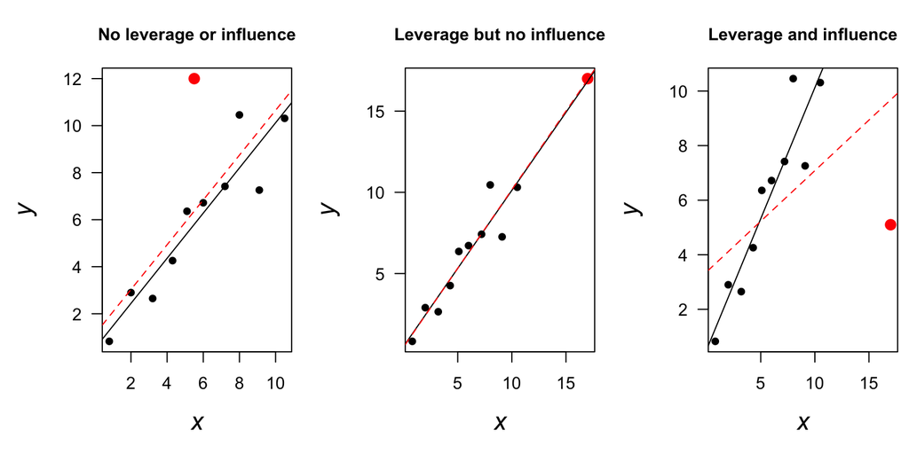

```r
## create data
xr <- round(1:10 + rnorm(10, 0, 0.2), 1)
simdata <- data.frame(x = xr,
                      y = xr + rnorm(10))
mm <- lm(y ~ x, simdata)
## no leverage or influence
p1 <- c(5.5,12)
m1 <- lm(y ~ x, rbind(simdata, p1))
## high leverage but no influence
p2 <- c(17,17)
m2 <- lm(y ~ x, rbind(simdata, p2))
## high leverage and influence
p3 <- c(17,5.1)
m3 <- lm(y ~ x, rbind(simdata, p3))
## set plot area
par(mfrow = c(1,3),
    mai = c(0.9, 0.9, 0.6, 0.1),
    omi = c(0, 0, 0, 0),
    cex = 0.9)
## plot examples
## no leverage or influence (left)
plot(y ~ x, rbind(simdata, p1), pch = 16, las = 1, xpd = NA,
     cex.lab = 1.5, xlab = expression(italic(x)), ylab = expression(italic(y)),
     main = "No leverage or influence", cex.main = 1)
points(5.5, 12, pch = 16, cex = 1.5, col ="red")
abline(mm)
abline(m1, lty=2, col ="red")
## high leverage but no influence (middle)
plot(y ~ x, rbind(simdata, p2), pch = 16, las = 1,
     cex.lab = 1.5, xlab = expression(italic(x)), ylab = expression(italic(y)),
     main = "Leverage but no influence", cex.main = 1)
points(17, 17, pch = 16, cex = 1.5, col ="red")
abline(mm)
abline(m2, lty=2, col ="red")
## high leverage and influence (right)
plot(y ~ x, rbind(simdata, p3), pch = 16, las = 1,
     cex.lab = 1.5, xlab = expression(italic(x)), ylab = expression(italic(y)),
     main = "Leverage and influence", cex.main = 1)
points(17, 5.1, pch = 16, cex = 1.5, col ="red")
abline(mm)
abline(m3, lty=2, col ="red")
```

## Identifying leverage points

Recall that we can use the “hat matrix” $(\mathbf{H})$ to project the $n$-dimensional data $\mathbf{y}$ onto the $k$-dimensional model.

As a reminder, for our linear model given by

$$\mathbf{y} = \mathbf{X} \boldsymbol{\beta} + \mathbf{e} \\
\mathbf{e} \sim \text{MVN}(\mathbf{0}, \sigma^2 \mathbf{I})$$

we have

$$\begin{align}
\mathbf{\hat{y}} &= \mathbf{X} \boldsymbol{\hat{\beta}} \\
&= \mathbf{X} \left( (\mathbf{X}^{\top} \mathbf{X})^{-1}
\mathbf{X}^{\top} \mathbf{y} \right) \\
&= \mathbf{X} (\mathbf{X}^{\top} \mathbf{X})^{-1}
\mathbf{X}^{\top} \mathbf{y} \\
&= \mathbf{H} \mathbf{y}
\end{align}$$

The values along the diagonal of $\mathbf{H}$ are known as the *leverages* (where $\mathbf{H}_{ii} = h_i$). These leverage values give an indication of the influence of a particular $x_{ij}$ on the model fit. The residuals are thus

$$\begin{aligned}
\mathbf{\hat{e}} &= \mathbf{e} \\
&= \mathbf{y} - \mathbf{\hat{y}} \\
&= \mathbf{y} - \mathbf{H} \mathbf{y} \\
&= \mathbf{y} (\mathbf{I} - \mathbf{H}).
\end{aligned}$$

From this it follows that

$$\begin{aligned}
\text{Var}(\mathbf{\hat{e}}) &= \text{Var}(\mathbf{e}) \\
&= \text{Var}(\mathbf{y} (\mathbf{I} - \mathbf{H})) \\
&= (\mathbf{I} - \mathbf{H}) \text{Var}(\mathbf{y} ) (\mathbf{I} -
\mathbf{H})^{\top} \\
&= \sigma^2 (\mathbf{I} - \mathbf{H})^2 \\
&= \sigma^2 (\mathbf{I} - \mathbf{H})
\end{aligned}$$

and therefore the variance of an individual residual is

$$\text{Var}(\widehat{e}_{i}) = \sigma^2 (1 - h_i).$$

From this relationship we can see that large $h_i$ lead to small variances of $\hat{e}_i$ & hence $\hat{y}_i$ tends to $y_i$. The hat matrix $\mathbf{H}$ has dimensions $n \times n$ and

$$\text{trace}(\mathbf{H}) = \sum_{i = 1}^n h_i = k$$

Thus, on average we should expect that the average leverage value is $\bar{h}_i = \frac{k}{n}$. Any $h_i > \frac{2 k}{n}$ deserve closer inspection.

Compute the $h_i$ in **R** via the function `hatvalues()`.

```r
## leverages of points in middle plot above
hv <- hatvalues(m2)
## trace(H) = number of parameters in the model
k <- sum(hv)
## expected value for h_i (~= 0.36)
Eh <- 2 * (k / length(hv))
## are any h_i > Eh?
hv > Eh
```

```
##     1     2     3     4     5     6     7     8     9    10    11
## FALSE FALSE FALSE FALSE FALSE FALSE FALSE FALSE FALSE FALSE  TRUE
```

We can also plot the individual leverage values to see whether they exceed their expectation, or identify high leverage via a half-normal plot.

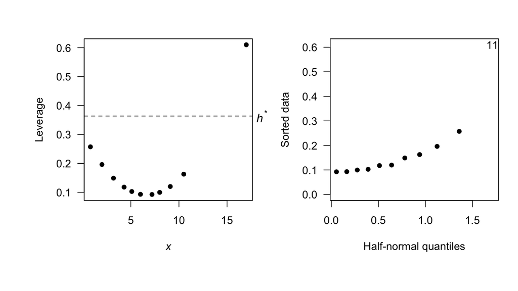

```r
## revised `halfnorm()` from Faraway
## `nlab` gives the number of points to label in the plot
## `labels` can be a character vector the same length as `x`
##          that can be used to label the points in the plot
## `ylab` can be used to labeling of the y-axis
halfnorm <- function(x, nlab = 1, labels = NULL, ylab = "Sorted data") {
  x <- abs(x)
  labord <- order(x)
  x <- sort(x)
  i <- order(x)
  n <- length(x)
  ui <- qnorm((n + 1:n)/(2 * n + 1))
  if(is.null(labels)) {
    labels <- as.character(1:length(x))
  }
  plot(ui, x[i], pch = 16, las = 1,
       xlab = "Half-normal quantiles", ylab = ylab,
       ylim = c(0, max(x)), type = "n")
  if(nlab < n) {
    points(ui[1:(n - nlab)], x[i][1:(n - nlab)], pch = 16)
  }
  text(x = ui[(n - nlab + 1):n], y = x[i][(n - nlab + 1):n],
       labels = labels[labord][(n - nlab + 1):n])
}
## set plot area
par(mfrow = c(1,2),
    mai = c(0.9,0.9,0.1,0.3),
    omi = c(0.5, 0.4, 0.5, 0),
    cex = 1)
## plot of inidivdual leverages (left)
plot(model.matrix(m2)[,2], hv, pch = 16, las = 1,
     ylab = "Leverage", xlab = expression(italic(x)))
mtext(expression(italic(h)^{"*"}), 4, line = 0.3, cex = 1.1, at = Eh, las = 1)
abline(h = Eh, lty = "dashed")
## half-normal plot of the leverages (right)
halfnorm(hv)
```

## Identifying outliers

We saw in lecture that we can standardize the model residuals to help identify outliers. Specifically, we can use the leverages to do so, such that the *studentized residual* $t_i$ is given by

$$t_i = \frac{y_{i} - \hat{y}_{(i)}}{ \hat{\sigma}_{(i)} \sqrt{ 1 - h_i }
} = e_i \sqrt{ \frac{n - k - 1}{n - k - e_i^2} }$$

and $e_i$ is the residual for the $i$<sup>th</sup> case based on a model that includes *all* of the data. This $t_i$ statistic is distributed as a $t$-distribution with $n - k - 1$ degrees of freedom.

Note, however, that this requires us to undertake $n$ different null hypothesis tests. Thus, if we chose a Type-I error rate of $\alpha$ = 0.05, we should expect that 1 in 20 of these tests would be significant by chance alone. To account for all of these tests, we can employ a *Bonferroni correction*, which instead sets the threshold at $\alpha_B = \alpha / n$. This correction factor comes up elsewhere in statistical testing and is known to be conservative; it finds fewer outliers than the nominal level of confidence would.

Computing the studentized residuals in **R** is easy with the `rstudent()` function. We can then compare them to the critical $t$ value with `qt()`.

Computing the studentized residuals for case #1 above (left-hand plot).

```r
## get sample size
n_m1 <- nrow(model.matrix(m1))
## get studentized e
t_stud <- rstudent(m1)
## Bonferroni alpha
alpha <- 0.05 / n_m1
## critical t value
df <- n_m1 - length(coef(m1)) - 1
t_crit <- qt(1 - alpha/2, df)
## compare t_stud to t_crit
t_stud > t_crit
```

```
##     1     2     3     4     5     6     7     8     9    10    11
## FALSE FALSE FALSE FALSE FALSE FALSE FALSE FALSE FALSE FALSE  TRUE
```

We can see that the 11<sup>th</sup> datum is an outlier (as we suspected from the above plot).

## Identifying influential observations

Influential observations might not be outliers nor have high leverage, but we want to identify them anyway. We saw in lecture that Cook’s Distance $(D)$ is a popular choice, where

$$D_i = e_i^2 \frac{1}{k} \left( \frac{h_i}{1 - h_i} \right).$$

The idea here is that $D_i$ combines the magnitude of a residual and its leverage. It’s easy to calculate the $D_i$ with the `cooks.distance()` function. We can then visually inspect $D$ with a half-normal plot (we’ll label the 2 values with the highest $D$ by setting `nlab = 2`).

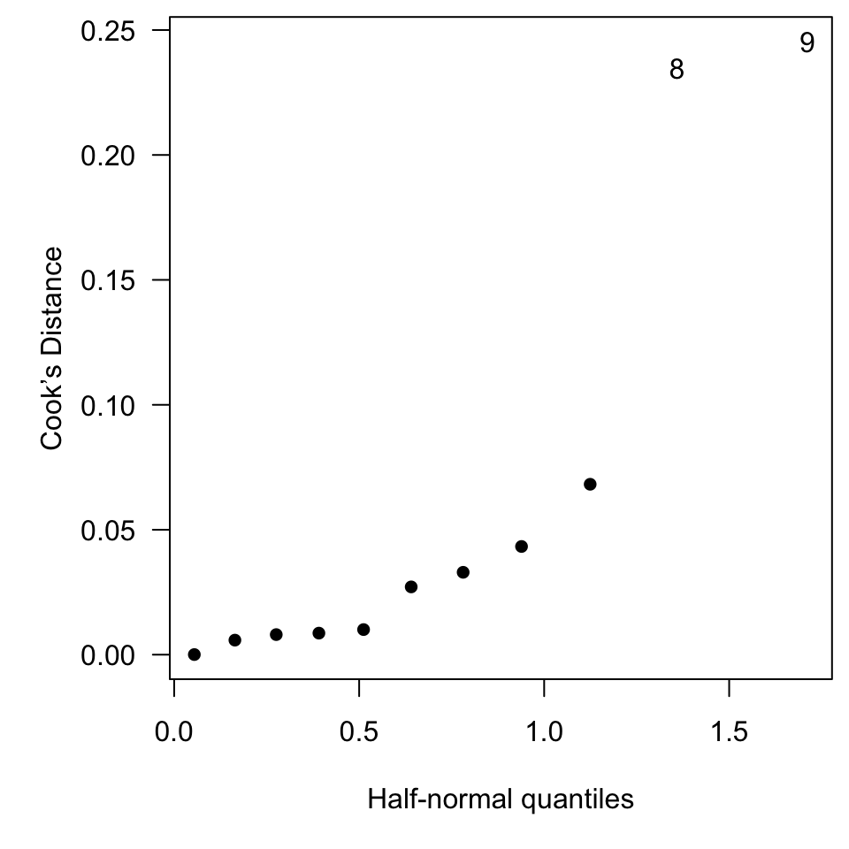

```r
## Cook's D
cook <- cooks.distance(m2)
## half-normal plot
par(mai = c(1,1,0.1,0.1),
    omi = c(0, 0, 0, 0),
    cex = 1)
halfnorm(cook, nlab = 2, ylab = "Cook’s Distance")
```

# Problems with errors

The models we have been using assume that the errors are independent and identically distributed (IID). Let’s explore some of the options for dealing with situations where those assumptions may be violated.

## Weighted least squares

In cases where the errors are independent, but *not* identically distributed, we can use weighted least squares. Let’s consider a data set from the famous statistician [Francis Galton](https://en.wikipedia.org/wiki/Francis_Galton), which contains information he collected on the size of pea seeds in parent plants and their offspring plants, and the frequency of each of the paired measurements. The data are contained in the accompanying file `galton_peas.csv`.

Begin by reading in the data and plotting them.

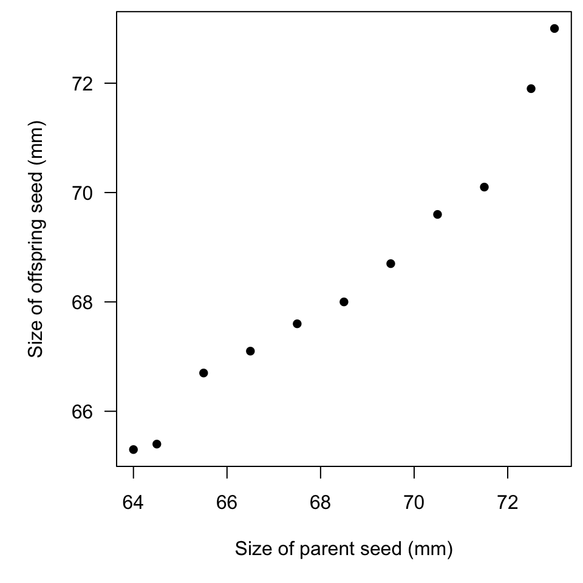

```r
## read data file
peas <- read.csv("galton_peas.csv")
## set plot area
par(mai = c(1,1,0.1,0.1),
    omi = c(0, 0, 0, 0),
    cex = 1)
## plot the data
plot(peas$parent, peas$offspring, pch = 16, las = 1,
     xlab = "Size of parent seed (mm)", ylab = "Size of offspring seed (mm)")
```

Each of the $y_i$ here is actually a weighted mean of the offspring pea size in each of the parent size groups, so we should use a weighted regression with $w_i = 1 / n_i$. This is easy to do with `lm()` by passing an additional `weights` argument. We’ll also fit a regular unweighted model for comparison.

```r
## fit weighted regression
mpw <- lm(offspring ~ parent, peas, weights = 1/n)
faraway::sumary(mpw)
```

```
##              Estimate Std. Error t value  Pr(>|t|)
## (Intercept) 10.481595   2.817401  3.7203  0.004768
## parent       0.852906   0.040052 21.2951 5.217e-09
##
## n = 11, p = 2, Residual SE = 0.10594, R-Squared = 0.98
```

```r
## compare to unweighted regression
mp <- lm(offspring ~ parent, peas)
faraway::sumary(mp)
```

```
##              Estimate Std. Error t value  Pr(>|t|)
## (Intercept) 16.042402   3.822194  4.1972  0.002316
## parent       0.765672   0.055744 13.7354 2.418e-07
##
## n = 11, p = 2, Residual SE = 0.55883, R-Squared = 0.95
```

Our weighted regression has a much lower `Residual SE` $(\widehat{\sigma}^2)$ and the parameter estimates are different as well.

## Robust regression

We saw in lecture that we can use robust regression in cases where the errors follow a non-normal distribution. Recall that the idea is to replace the squared function in our estimate of $SSE$ with some other function.

### Huber’s method

One of the possibilities is *Huber’s method* where

$$SSE = \sum^n_{i = 1} f(z) \\
~ \\
f(z) = \left\{
\begin{matrix}
\frac{z^2}{2} & \text{if} ~ \left| z \right| \leq c \\
c \left| z \right| - \frac{c^2}{2} & \text{otherwise}
\end{matrix}
\right.$$

and $c = \widehat{\sigma} \propto \text{Median}(\left| \widehat{e} \right|)$.

As an example, let’s return to the plant data from the Galapagos Archipelago that we used last week in lab.

Begin by fitting a normal regression model and plot the residuals against the fitted values.

```r
## get the data
library(faraway)
head(gala)
```

```
##              Species Endemics  Area Elevation Nearest Scruz Adjacent
## Baltra            58       23 25.09       346     0.6   0.6     1.84
## Bartolome         31       21  1.24       109     0.6  26.3   572.33
## Caldwell           3        3  0.21       114     2.8  58.7     0.78
## Champion          25        9  0.10        46     1.9  47.4     0.18
## Coamano            2        1  0.05        77     1.9   1.9   903.82
## Daphne.Major      18       11  0.34       119     8.0   8.0     1.84
```

```r
## fit normal regr model
gm <- lm(Species ~ Area, gala)
## examine fit
sumary(gm)
```

```
##              Estimate Std. Error t value  Pr(>|t|)
## (Intercept) 63.782861  17.524416  3.6397 0.0010943
## Area         0.081963   0.019713  4.1578 0.0002748
##
## n = 30, p = 2, Residual SE = 91.73159, R-Squared = 0.38
```

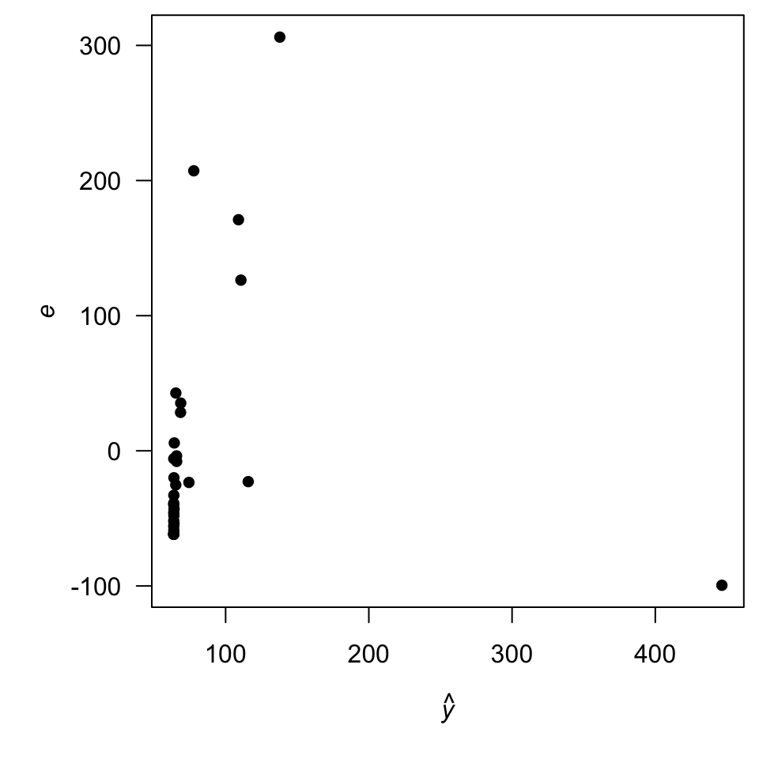

```r
## set plot area
par(mai = c(1,1,0.1,0.1),
    omi = c(0, 0, 0, 0),
    cex = 1)
## plot residuals vs y_hat
plot(fitted(gm), resid(gm), pch = 16, las = 1,
     ylab = expression(italic(e)), xlab = expression(hat(italic(y))))
```

This plot reveals some obvious problems with our model assumptions, so now let’s fit our robust model. To do so, we can use the `rlm()` function in the **MASS** package, wherein the default option is to use Huber’s method.

```r
## fit robust regr model
rgm <- MASS::rlm(Species ~ Area, gala)
## examine fit
summary(rgm)
```

```
##
## Call: rlm(formula = Species ~ Area, data = gala)
## Residuals:
##    Min     1Q Median     3Q    Max
## -42.92 -32.87 -10.07  22.40 334.29
##
## Coefficients:
##             Value   Std. Error t value
## (Intercept) 44.9056  8.8575     5.0698
## Area         0.0717  0.0100     7.1965
##
## Residual standard error: 48.67 on 28 degrees of freedom
```

Here we see that the parameter estimates have changed somewhat and the estimate of the residual standard error has decreased substantially. Let’s go a step further and find out which of the islands had high influence and hence low weighting.

```r
## extract weights from model fit
wts <- round(rgm$w, 2)
names(wts) <- row.names(gala)
## sort and inspect them
sort(wts)
```

```
##    SantaCruz   SantaMaria SanCristobal  SanSalvador       Baltra    Bartolome
##         0.20         0.29         0.33         0.43         1.00         1.00
##     Caldwell     Champion      Coamano Daphne.Major Daphne.Minor       Darwin
##         1.00         1.00         1.00         1.00         1.00         1.00
##         Eden      Enderby     Espanola   Fernandina     Gardner1     Gardner2
##         1.00         1.00         1.00         1.00         1.00         1.00
##     Genovesa      Isabela     Marchena       Onslow        Pinta       Pinzon
##         1.00         1.00         1.00         1.00         1.00         1.00
##   Las.Plazas       Rabida      SantaFe      Seymour      Tortuga         Wolf
##         1.00         1.00         1.00         1.00         1.00         1.00
```

Four of the islands have been discounted in the estimation procedure.

### Least trimmed squares

M-estimation will fail if the large errors are numerous and extreme in value. If this is the case, then we can use *least trimmed squares* (LTS) as a resistant regression method that deals well with this situation. LTS minimizes the sum of squares of the $q$ smallest residuals, such that

$$SSE = \sum^n_{i = 1} e^2_{i} ~ \rightarrow ~ SSE_q = \sum^q_{i = 1}
e^2_{(i)}$$

and $(i)$ indicates the residuals are sorted in ascending order. The default is $q = \lfloor n/2 \rfloor + \lfloor (k + 1) / 2 \rfloor$ where $\lfloor \cdot \rfloor$ is the floor function, which always rounds a number down to the nearest integer (type `?floor` for help on this function in **R**).

We can fit an LTS model with the `ltsreg()` function in the **MASS** package.

Fit an LTS model to the Galapagos plant data and examine the estimated parameters.

```r
## fit LTS model
ltm <- MASS::ltsreg(Species ~ Area, gala)
## examine fit
coef(ltm)
```

```
## (Intercept)        Area
##    8.400631    1.616162
```

This method does not automatically report the uncertainty in the parameter estimates, but we can use our bootstrapping method to estimate a confidence interval around them.

```r
## number of boostrap samples
nb <- 1000
## empty matrix for beta estimates
beta_est <- matrix(NA, nb, 2)
## residuals from our model
resids <- residuals(ltm)
## sample many times
for(i in 1:nb) {
  ## sample w/ replacement from e
  e_star <- sample(resids, rep = TRUE)
  ## calculate y_star
  y_star <- predict(ltm) + e_star
  ## re-estimate model
  beta_star <- MASS::ltsreg(y_star ~ Area, gala)
  ## save estimated betas
  beta_est[i,] <- coef(beta_star)
}
## extract 2.5% and 97.5% values (with the median)
CI95 <- cbind(sort(beta_est[,1])[c(25, 500, 975)],
              sort(beta_est[,2])[c(25, 500, 975)])
colnames(CI95) <- c("Intercept", "Area")
rownames(CI95) <- c("lower 95%", "median", "upper 95%")
t(round(CI95, 2))
```

```
##           lower 95% median upper 95%
## Intercept      3.82   8.49     19.03
## Area           1.60   1.62      1.67
```